# solutions assignment_01

Updated 2020-03-10

## Assignment 01

Below are 6 exercises to help you practice vectorizing for-loops, and converting for-loops into vectorized expressions using `purrr` functions. This assignment was designed to be completed in about 60 minutes and is deliberately designed to be shorter to accommodate the team project.

```r
library(tidyverse)
mtcars_original <- mtcars
```

### Task 1: Convert for-loop code to vectorized expressions using `purrr` functions

#### 1.1 - Below is sample code that computes the mean of every column in the `mtcars` dataset. Use the appropriate `purrr` function to vectorize this task.

```r
output <- vector("double", ncol(mtcars))
for (c in seq_along(mtcars)){
  output[[c]] <- mean(mtcars[[c]])
}
output
```

```
##  [1]  20.090625   6.187500 230.721875 146.687500   3.596563   3.217250
##  [7]  17.848750   0.437500   0.406250   3.687500   2.812500
```

Your solution to vectorize the code above (using a `purrr` function):

```r
# add solution here
# BEGIN SOLUTION
output <- function(df){
  return(map(df, mean))
  }
# END SOLUTION
```

#### 1.2 - Below is sample code that divides the values in each column of the `mtcars` dataset by the maximum in that column. Use the appropriate `purrr` function to vectorize this task.

```r
for (c in seq_along(mtcars)){
  mtcars[[c]] <- mtcars[[c]] / max(mtcars[[c]], na.rm = TRUE)
}
head(mtcars)
```

```
##                         mpg  cyl      disp        hp      drat        wt
## Mazda RX4         0.6194690 0.75 0.3389831 0.3283582 0.7910751 0.4830383
## Mazda RX4 Wag     0.6194690 0.75 0.3389831 0.3283582 0.7910751 0.5300516
## Datsun 710        0.6725664 0.50 0.2288136 0.2776119 0.7809331 0.4277286
## Hornet 4 Drive    0.6312684 0.75 0.5466102 0.3283582 0.6247465 0.5927360
## Hornet Sportabout 0.5516224 1.00 0.7627119 0.5223881 0.6389452 0.6342183
## Valiant           0.5339233 0.75 0.4766949 0.3134328 0.5598377 0.6379056
##                        qsec vs am gear  carb
## Mazda RX4         0.7187773  0  1  0.8 0.500
## Mazda RX4 Wag     0.7432314  0  1  0.8 0.500
## Datsun 710        0.8126638  1  1  0.8 0.125
## Hornet 4 Drive    0.8489083  1  0  0.6 0.125
## Hornet Sportabout 0.7432314  0  0  0.6 0.250
## Valiant           0.8829694  1  0  0.6 0.125
```

Your solution to vectorize the code above (using a `purrr` function):

```r
# add solution here
output <- map(mtcars, ~./max(.))
output
```

```
## $mpg
##  [1] 0.6194690 0.6194690 0.6725664 0.6312684 0.5516224 0.5339233 0.4218289
##  [8] 0.7197640 0.6725664 0.5663717 0.5250737 0.4837758 0.5103245 0.4483776
## [15] 0.3067847 0.3067847 0.4336283 0.9557522 0.8967552 1.0000000 0.6342183
## [22] 0.4572271 0.4483776 0.3923304 0.5663717 0.8053097 0.7669617 0.8967552
## [29] 0.4660767 0.5811209 0.4424779 0.6312684
##
## $cyl
##  [1] 0.75 0.75 0.50 0.75 1.00 0.75 1.00 0.50 0.50 0.75 0.75 1.00 1.00 1.00 1.00
## [16] 1.00 1.00 0.50 0.50 0.50 0.50 1.00 1.00 1.00 1.00 0.50 0.50 0.50 1.00 0.75
## [31] 1.00 0.50
##
## $disp
##  [1] 0.3389831 0.3389831 0.2288136 0.5466102 0.7627119 0.4766949 0.7627119
##  [8] 0.3108051 0.2983051 0.3550847 0.3550847 0.5843220 0.5843220 0.5843220
## [15] 1.0000000 0.9745763 0.9322034 0.1667373 0.1603814 0.1506356 0.2544492
## [22] 0.6737288 0.6440678 0.7415254 0.8474576 0.1673729 0.2548729 0.2014831
## [29] 0.7436441 0.3072034 0.6377119 0.2563559
##
## $hp
##  [1] 0.3283582 0.3283582 0.2776119 0.3283582 0.5223881 0.3134328 0.7313433
##  [8] 0.1850746 0.2835821 0.3671642 0.3671642 0.5373134 0.5373134 0.5373134
## [15] 0.6119403 0.6417910 0.6865672 0.1970149 0.1552239 0.1940299 0.2895522
## [22] 0.4477612 0.4477612 0.7313433 0.5223881 0.1970149 0.2716418 0.3373134
## [29] 0.7880597 0.5223881 1.0000000 0.3253731
##
## $drat
##  [1] 0.7910751 0.7910751 0.7809331 0.6247465 0.6389452 0.5598377 0.6511156
##  [8] 0.7484787 0.7951318 0.7951318 0.7951318 0.6227181 0.6227181 0.6227181
## [15] 0.5943205 0.6085193 0.6551724 0.8275862 1.0000000 0.8559838 0.7505071
## [22] 0.5598377 0.6389452 0.7565923 0.6247465 0.8275862 0.8985801 0.7647059
## [29] 0.8559838 0.7342799 0.7180527 0.8336714
##
## $wt
##  [1] 0.4830383 0.5300516 0.4277286 0.5927360 0.6342183 0.6379056 0.6581858
##  [8] 0.5881268 0.5807522 0.6342183 0.6342183 0.7503687 0.6876844 0.6969027
## [15] 0.9679204 1.0000000 0.9854351 0.4056047 0.2977507 0.3383112 0.4544617
## [22] 0.6489676 0.6332965 0.7079646 0.7088864 0.3567478 0.3945428 0.2789454
## [29] 0.5844395 0.5106932 0.6581858 0.5125369
##
## $qsec
##  [1] 0.7187773 0.7432314 0.8126638 0.8489083 0.7432314 0.8829694 0.6917031
##  [8] 0.8733624 1.0000000 0.7991266 0.8253275 0.7598253 0.7685590 0.7860262
## [15] 0.7851528 0.7781659 0.7606987 0.8502183 0.8087336 0.8689956 0.8737991
## [22] 0.7366812 0.7554585 0.6729258 0.7445415 0.8253275 0.7292576 0.7379913
## [29] 0.6331878 0.6768559 0.6375546 0.8122271
##
## $vs
##  [1] 0 0 1 1 0 1 0 1 1 1 1 0 0 0 0 0 0 1 1 1 1 0 0 0 0 1 0 1 0 0 0 1
##
## $am
##  [1] 1 1 1 0 0 0 0 0 0 0 0 0 0 0 0 0 0 1 1 1 0 0 0 0 0 1 1 1 1 1 1 1
##
## $gear
##  [1] 0.8 0.8 0.8 0.6 0.6 0.6 0.6 0.8 0.8 0.8 0.8 0.6 0.6 0.6 0.6 0.6 0.6 0.8 0.8
## [20] 0.8 0.6 0.6 0.6 0.6 0.6 0.8 1.0 1.0 1.0 1.0 1.0 0.8
##
## $carb
##  [1] 0.500 0.500 0.125 0.125 0.250 0.125 0.500 0.250 0.250 0.500 0.500 0.375
## [13] 0.375 0.375 0.500 0.500 0.500 0.125 0.250 0.125 0.125 0.250 0.250 0.500
## [25] 0.250 0.125 0.250 0.250 0.500 0.750 1.000 0.250
```

#### 1.3 - Below is sample code that creates a ggplot with fuel efficiency on the x-axis and horsepower on the y-axis for three cylinder levels (4, 6, 8). Use the appropriate `purrr` function to vectorize this task.

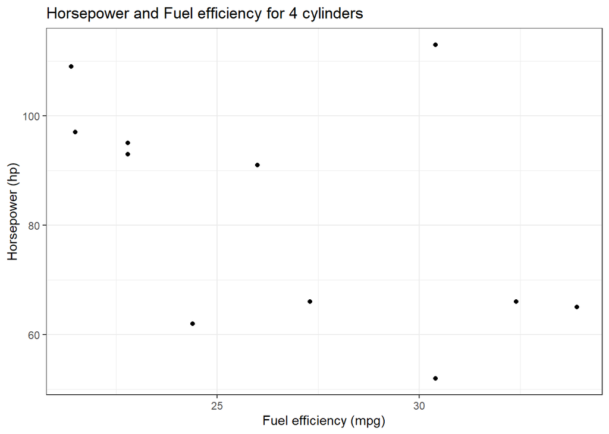

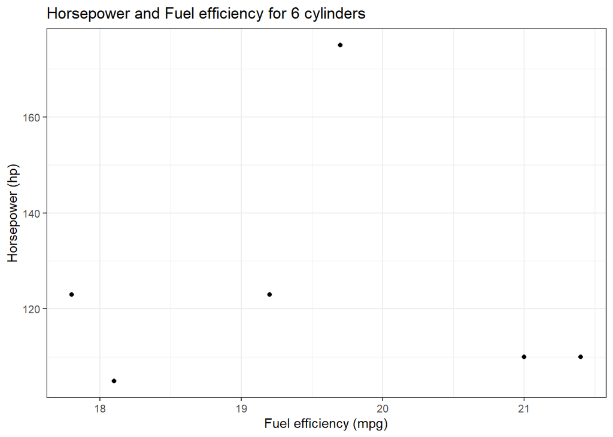

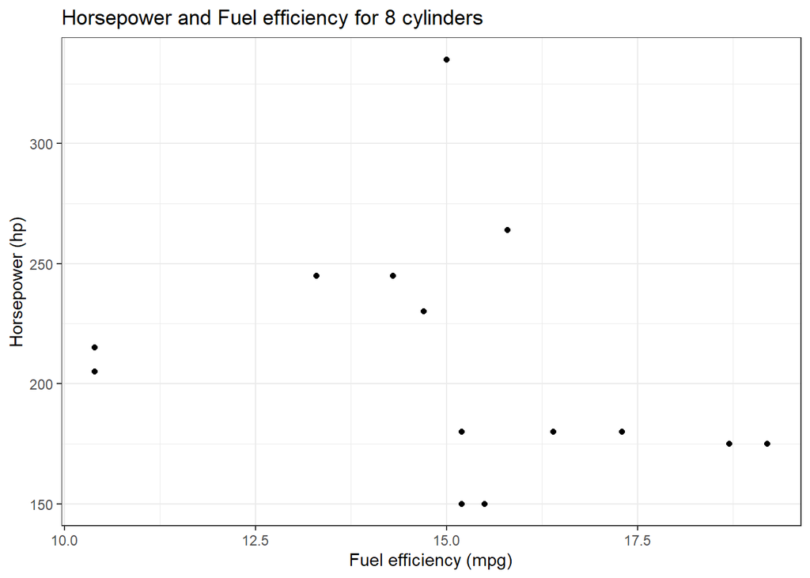

```r
cylinders <- sort(unique(mtcars_original[['cyl']]))
plots <- vector("list",length(cylinders))
for (d in 1:length(cylinders)){
  plots[[d]] <- mtcars_original %>%
    filter(cyl == cylinders[d]) %>%
    ggplot() +
    theme_bw() +
    geom_point(aes(x = mpg, y = hp) ) +
    labs(x = 'Fuel efficiency (mpg)',
         y = 'Horsepower (hp)') +
    ggtitle(glue::glue("Horsepower and Fuel efficiency for ", cylinders[d], " cylinders"))
}
plots
```

Your solution to vectorize the code above (using a `purrr` function):

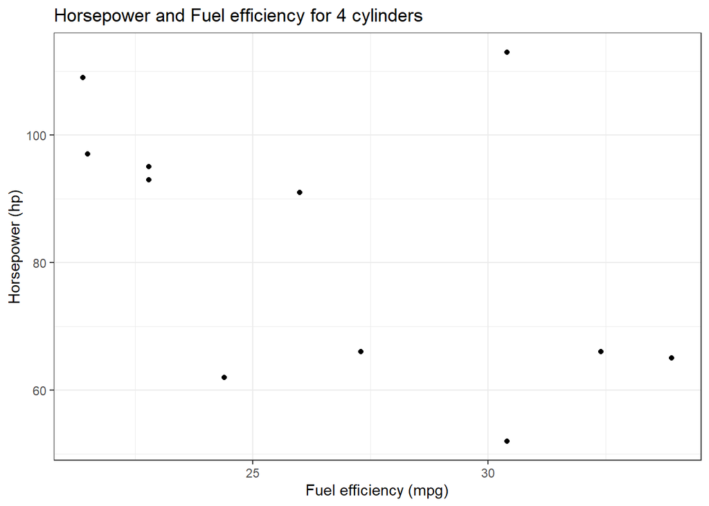

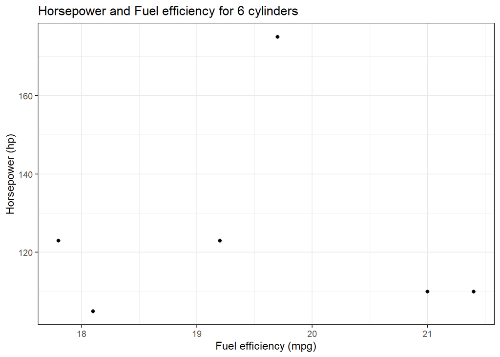

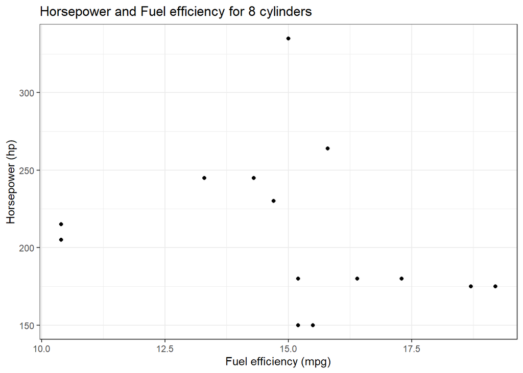

```r
# add solution here
cylinders <- sort(unique(mtcars_original[['cyl']]))
output <- map(1:length(cylinders), ~ mtcars_original %>%
    filter(cyl == cylinders[.x]) %>%
    ggplot() +
    theme_bw() +
    geom_point(aes(x = mpg, y = hp) ) +
    labs(x = 'Fuel efficiency (mpg)',
         y = 'Horsepower (hp)') +
    ggtitle(glue::glue("Horsepower and Fuel efficiency for ", cylinders[.x], " cylinders")))
output
```

```r
### END SOLUTION
```

### Task 2: Convert vectorized expressions into one that uses for-loops

#### 2.1 - Below is sample code that computes the number of unique values in each column of `mtcars` in a vectorized way. Turn this vectorized expression into one that uses for-loop(s) that reproduces the output (numbers should be the same, the format can be different).

```r
map(mtcars_original, unique) %>%
  map_dbl(length)
```

```
##  mpg  cyl disp   hp drat   wt qsec   vs   am gear carb
##   25    3   27   22   22   29   30    2    2    3    6
```

Your solution to “un-vectorize” the code above using for-loops:

```r
# add solution here
output <- vector("double", ncol(mtcars_original))
for (c in seq_along(mtcars_original)){
  output[[c]] <- length(unique((mtcars_original[[c]])))
}
names(output)=names(mtcars_original)
output
```

```
##  mpg  cyl disp   hp drat   wt qsec   vs   am gear carb
##   25    3   27   22   22   29   30    2    2    3    6
```

#### 2.2 - Below is sample code that takes input from various columns in the `diamonds` dataset and outputs a string containing information from the input. Turn this vectorized expression into one that uses for-loop(s) that reproduces the output (numbers should be the same, the format can be different).

*Hint:* Note the use of `pmap_chr` to iterate over three columns (diamond number, price and carat).

```r
dmonds <- diamonds %>%
  slice(1:4)
list_of_things <- list(seq(nrow(dmonds)), dmonds$price, dmonds$carat)
output <- pmap_chr( list_of_things,
                   ~paste0("Diamond #", ..1 ,
                           " sold for $",..2,
                           " and was ",..3, " carats"))
output
```

```
## [1] "Diamond #1 sold for $326 and was 0.23 carats"
## [2] "Diamond #2 sold for $326 and was 0.21 carats"
## [3] "Diamond #3 sold for $327 and was 0.23 carats"
## [4] "Diamond #4 sold for $334 and was 0.29 carats"
```

Your solution to “un-vectorize” the code above using for-loops:

```r
output <- list("character", nrow(dmonds))
for (d in 1:nrow(dmonds)){
  output[d] <- paste0("Diamond #", d ,
                      " sold for $", dmonds$price[d],
                      " and was ", dmonds$carat[d], " carats")
}
### END SOLUTION
unlist(output)
```

```
## [1] "Diamond #1 sold for $326 and was 0.23 carats"
## [2] "Diamond #2 sold for $326 and was 0.21 carats"
## [3] "Diamond #3 sold for $327 and was 0.23 carats"
## [4] "Diamond #4 sold for $334 and was 0.29 carats"
```

#### 2.3 - Below is sample code that splits the iris dataset into three species, and saves each dataframe as a separate file. Turn this vectorized expression into one that uses a for-loop that reproduces the output.

*Hint 1*: `map2(x, y, f)` is the same as `pmap(list(x, y), f)`

*Hint 2*: Multiple files can be saved in a vectorized way using the`pmap` function. The [`nest` function](https://tidyr.tidyverse.org/reference/nest.html) is used to create a list-column of data frames for each species from the `iris` dataset.

```r
iris %>%
  nest(data = -Species) %>%
  pmap(~write_csv(.y, path = here::here(glue::glue(.x, ".csv"))))
```

```
## [[1]]
## # A tibble: 50 x 4
##    Sepal.Length Sepal.Width Petal.Length Petal.Width
##           <dbl>       <dbl>        <dbl>       <dbl>
##  1          5.1         3.5          1.4         0.2
##  2          4.9         3            1.4         0.2
##  3          4.7         3.2          1.3         0.2
##  4          4.6         3.1          1.5         0.2
##  5          5           3.6          1.4         0.2
##  6          5.4         3.9          1.7         0.4
##  7          4.6         3.4          1.4         0.3
##  8          5           3.4          1.5         0.2
##  9          4.4         2.9          1.4         0.2
## 10          4.9         3.1          1.5         0.1
## # ... with 40 more rows
##
## [[2]]
## # A tibble: 50 x 4
##    Sepal.Length Sepal.Width Petal.Length Petal.Width
##           <dbl>       <dbl>        <dbl>       <dbl>
##  1          7           3.2          4.7         1.4
##  2          6.4         3.2          4.5         1.5
##  3          6.9         3.1          4.9         1.5
##  4          5.5         2.3          4           1.3
##  5          6.5         2.8          4.6         1.5
##  6          5.7         2.8          4.5         1.3
##  7          6.3         3.3          4.7         1.6
##  8          4.9         2.4          3.3         1
##  9          6.6         2.9          4.6         1.3
## 10          5.2         2.7          3.9         1.4
## # ... with 40 more rows
##
## [[3]]
## # A tibble: 50 x 4
##    Sepal.Length Sepal.Width Petal.Length Petal.Width
##           <dbl>       <dbl>        <dbl>       <dbl>
##  1          6.3         3.3          6           2.5
##  2          5.8         2.7          5.1         1.9
##  3          7.1         3            5.9         2.1
##  4          6.3         2.9          5.6         1.8
##  5          6.5         3            5.8         2.2
##  6          7.6         3            6.6         2.1
##  7          4.9         2.5          4.5         1.7
##  8          7.3         2.9          6.3         1.8
##  9          6.7         2.5          5.8         1.8
## 10          7.2         3.6          6.1         2.5
## # ... with 40 more rows
```

Your solution to “un-vectorize” the code above using for-loops:

```r
# add solution here

sp_list  <- unique(iris[['Species']])
  for (i in seq_along(sp_list)){
    iris %>%
      filter(Species==sp_list[[i]]) %>%
      write_csv(., path = here::here(glue::glue(sp_list[[i]], ".csv")))
  }
```

## Additional Resources

1. Chapter 21 of [R for Data Science](https://r4ds.had.co.nz/iteration.html).
2. [Learn to purr](http://www.rebeccabarter.com/blog/2019-08-19_purrr/) blog post.
3. Chapter 9 of [Advanced R for Data Science](https://adv-r.hadley.nz/functionals.html).